# SCA_PPATpy27

## SCA6.0 - PPAT py2.7 code

**Summary:** This script is based off of the analysis of the S1A serine protease family:

```
-  Halabi, Rivoire, Leibler and Ranganathan. (2009) Cell 138:774-786.
```

Prior to running this tutorial, the core calculation scripts must be executed from the command line as follows:

```
>> python annotate_MSA.py Inputs/PPAT_align_clean.fasta -o Inputs/PPAT.an -a 'ncbi' -g Inputs/PPAT_align_clean_gi_list.txt
>> python scaProcessMSA.py Inputs/PPAT.an -f 'Escherichia coli' -i 451
>> python scaCore.py Outputs/PPAT.db
>> python scaSectorID.py Outputs/PPAT.db
```

```python
%matplotlib inline
from __future__ import division

import os
import time
import matplotlib.pyplot as plt
import numpy as np
import copy
import scipy.cluster.hierarchy as sch
from scipy.stats import scoreatpercentile
import matplotlib.image as mpimg
from IPython.display import display
from IPython.display import Image
from Bio.Seq import Seq
from Bio import motifs
import colorsys
import scaTools as sca
import mpld3
import cPickle as pickle
from optparse import OptionParser

if not os.path.exists('Outputs/'): os.makedirs('Outputs/')
```

```python
db = pickle.load(open('Outputs/PPAT.db','rb'))
Dseq = db['sequence']  #the results of scaProcessMSA
Dsca = db['sca']       #the results of scaCore
Dsect = db['sector']   #the results of scaSectorID
```

### I. Alignment processing and composition

First, we print out a few statistics describing the alignment:

```python
print("After processing, the alignment size is %i sequences and %i positions" % \
      (Dseq['Nseq'], Dseq['Npos']))
print("With sequence weights, there are %i effective sequences" % (Dseq['effseqs']))
```

```
After processing, the alignment size is 452 sequences and 153 positions
With sequence weights, there are 347 effective sequences
```

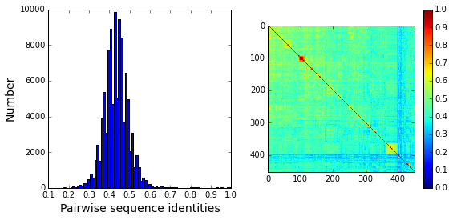

```python
# List all elements above the diagonal (i<j):
listS = [Dsca['simMat'][i,j] for i in range(Dsca['simMat'].shape[0]) \
         for j in range(i+1, Dsca['simMat'].shape[1])]
#Cluster the sequence similarity matrix
Z = sch.linkage(Dsca['simMat'],method = 'complete', metric = 'cityblock')
R = sch.dendrogram(Z,no_plot = True)
ind = map(int, R['ivl'])
#Plotting
plt.rcParams['figure.figsize'] = 9, 4
plt.subplot(121)
plt.hist(listS, int((Dseq['Npos']+1)/2))
plt.xlabel('Pairwise sequence identities', fontsize=14)
plt.ylabel('Number', fontsize=14)
plt.subplot(122)
plt.imshow(Dsca['simMat'][np.ix_(ind,ind)], vmin=0, vmax=1); plt.colorbar();
```

```python
#construct a dictionary of phylogenetic groups
annot = dict()
for i, h in enumerate(Dseq['hd']):
    hs = h.split('|')
    if (len(hs) == 4):
        annot[hs[0]] = sca.Annot(hs[1], hs[2], hs[3].replace('.',''))
    elif (len(hs) == 3):
        annot[hs[0]] = sca.Annot(hs[0],hs[1], hs[2].replace('.',''))

# Most frequent taxonomic groups:
atleast = 10
for level in range(4):
    descr_list = [a.taxo.split(',')[level] for a in annot.values() \
                  if len(a.taxo.split(',')) > level]
    descr_dict = {k:descr_list.count(k) for k in descr_list \
                  if descr_list.count(k)>=atleast}
    print '\n Level %i:' % level
    print descr_dict
```

```
 Level 0:
{'cellular organisms': 440}

 Level 1:
{' Bacteria': 440}

 Level 2:
{' Spirochaetes': 23, ' FCB group': 11, ' PVC group': 17, ' Proteobacteria': 130, ' Terrabacteria group': 214}

 Level 3:
{' Gammaproteobacteria': 30, ' Spirochaetia': 23, ' Firmicutes': 168, ' delta/epsilon subdivisions': 69, ' Actinobacteria': 21, ' Alphaproteobacteria': 20}
```

$\bullet$ $U^{(0)}$ and $U'^{(0)}$, the top eigenmodes and ICs without any weights;

$\bullet$ $U^{(1)}$ and $U'^{(1)}$ the top eigenmodes and ICs with sequences weights;

$\bullet$ $U^{(2)}$ and $U'^{(2)}$ the top eigenmodes and ICs with both sequences and positional weights.

The sequences are colored by weight, with red indicating the most strongly downweighted sequences. In contrast to the g-protein example, we see that application of the sequence and position weights makes the sequence space apparently more uniform (removes some of the family or clade-like structure).

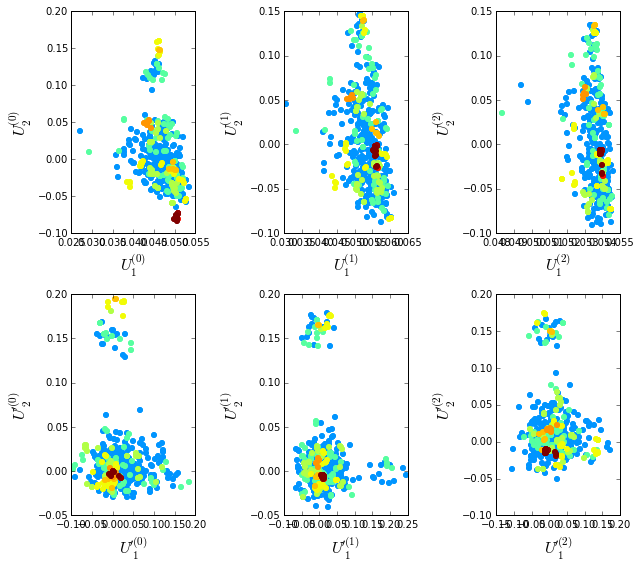

```python
Useq = Dsca['Useq']
Uica = Dsca['Uica']
plt.rcParams['figure.figsize'] = 9, 8
ica = ["","","","'","'","'"]
for k,U in enumerate(Useq+Uica):
    plt.subplot(2,3,k+1)
    sca.figWeights(U[:,0], U[:,1], Dseq['seqw'][0])
    plt.xlabel(r'${U%s}^{(%i)}_1$'%(ica[k],k%3), fontsize=16)
    plt.ylabel(r'${U%s}^{(%i)}_2$'%(ica[k],k%3), fontsize=16)
plt.tight_layout()
```

Based on this, we select taxonomic groups and colors for representation. Here, we just start by choosing the broadly well-represented groups. To see a complete color-coding legend, use:

```
>>> sca.figColors()
```

```python
phylo = list();
fam_names = ['Firmicutes', 'Actinobacteria', 'Gammaproteobacteria', \
             'Spirochaetia', 'Alphaproteobacteria','delta/epsilon']
col = (0, 0.18, 0.38, 0.5, 0.6, 1)
#Firmicutes = red, Actinobacteria = yellow, Gammaproteobacteria = cyan,
#Spirochaetia = green, Alphaproteobacteria = blue, delta/epsilon = black
for i,k in enumerate(fam_names):
    sf = sca.Unit()
    sf.name = fam_names[i].lower()
    sf.col = col[i]
    sf.items = [j for j,q in enumerate(Dseq['hd'])  if sf.name in q.lower()]
    phylo.append(sf)
```

Plot the top six independent components of the sequence correlation matrix (with sequence weights); color-coded by phylogenetic annotation.

```
[[0, 1], [2, 3], [4, 5]]
```

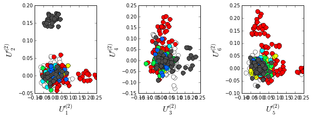

```python
plt.rcParams['figure.figsize'] = 9, 3.5
U = Dsca['Uica'][1]
pairs = [[2*i,2*i+1] for i in range(3)]
print pairs
for k,[k1,k2] in enumerate(pairs):
    plt.subplot(1,3,k+1)
    sca.figUnits(U[:,k1], U[:,k2], phylo)
    #sca.figUnits(U[:,k1], U[:,k2], subfam)
    plt.xlabel(r"${U'}^{(2)}_{%i}$"%(k1+1), fontsize=16)
    plt.ylabel(r"${U'}^{(2)}_{%i}$"%(k2+1), fontsize=16)
plt.tight_layout()
```

### II. First-order statistics: position-specific conservation.

Plot the position-specific conservation values for each PPAT protease position. $D_i$ is calculated according to equation S4 (supplemental information).

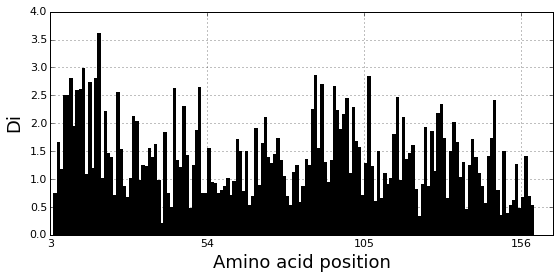

```python
fig, axs = plt.subplots(1,1, figsize=(9,4))
xvals = [i+1 for i in range(len(Dsca['Di']))]
xticks = [0,50,100,150]
plt.bar(xvals,Dsca['Di'], color='k')
plt.tick_params(labelsize=11); plt.grid()
axs.set_xticks(xticks);
labels = [Dseq['ats'][k] for k in xticks]
axs.set_xticklabels(labels);
plt.xlabel('Amino acid position', fontsize=18); plt.ylabel('Di', fontsize=18);
```

### III. Second-order statistics: conserved correlations.

Plot the SCA correlation matrix ( $\tilde{C_{ij}}$ ) computed according to Equations 4 + 5 of Rivoire et al.

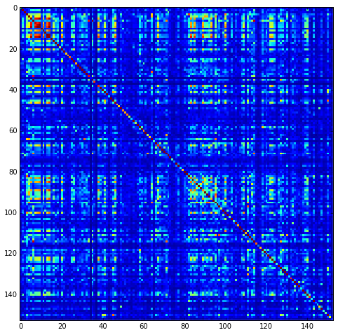

```python
plt.rcParams['figure.figsize'] = 9, 8
plt.imshow(Dsca['Csca'], vmin=0, vmax=1.4,interpolation='none',\
           aspect='equal')
```

Plot the eigenspectrum of (1) the SCA positional coevolution matrix ($\tilde{C_{ij}}$) *(black bars)* and (2) 10 trials of matrix randomization for comparison. This graph is used to choose the number of significant eigenmodes ($k^* = 7$).

```
Number of eigenmodes to keep is 7
```

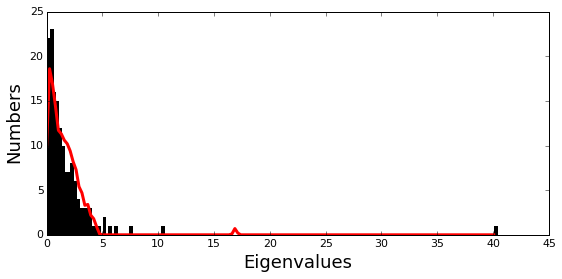

```python
plt.rcParams['figure.figsize'] = 9, 4
hist0, bins = np.histogram(Dsca['Lrand'].flatten(), bins=Dseq['Npos'], \
                           range=(0,Dsect['Lsca'].max()))
hist1, bins = np.histogram(Dsect['Lsca'], bins=Dseq['Npos'], \
                           range=(0,Dsect['Lsca'].max()))
plt.bar(bins[:-1], hist1, np.diff(bins),color='k')
plt.plot(bins[:-1], hist0/Dsca['Ntrials'], 'r', linewidth=3)
plt.tick_params(labelsize=11)
plt.xlabel('Eigenvalues', fontsize=18); plt.ylabel('Numbers', fontsize=18);
print 'Number of eigenmodes to keep is %i' %(Dsect['kpos'])
#mpld3.display()
```

Plot the top significant eigenmodes *(top row)* and associated independent components *(bottom row)*. The ICs are an optimally independent representation of the seven different residue groups.

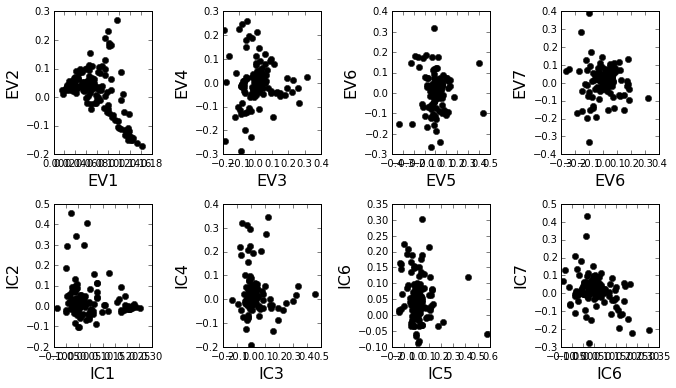

```python
plt.rcParams['figure.figsize'] = 9.5, 5.5
pairs = [[0,1],[2,3],[4,5],[5,6]]
EVs = Dsect['Vsca']
ICs = Dsect['Vpica']
for k,[k1,k2] in enumerate(pairs):
    plt.subplot(2,4,k+1)
    plt.plot(EVs[:,k1], EVs[:,k2], 'ok')
    plt.xlabel("EV%i"%(k1+1), fontsize=16)
    plt.ylabel("EV%i"%(k2+1), fontsize=16)
    plt.subplot(2,4,k+5)
    plt.plot(ICs[:,k1], ICs[:,k2], 'ok')
    plt.xlabel("IC%i"%(k1+1), fontsize=16)
    plt.ylabel("IC%i"%(k2+1), fontsize=16)
plt.tight_layout()
```